# Conserved_and_Diverged_Expression

Joe McGirr

2021-03-22

# Summary

This notebook visualizes transcriptomic responses to osmotic stress across 14 Killifish species.

##### Load functions and choose counts threshold

### Conserved expression response to osmotic stress across all species.

- Genes show the same response to osmotic stress across all species, regardless of native physiology.
- Same fold-change expression response to osmotic stress.
- Significant for main effect of treatment but not significant for (treatment x physiology) and not significant for (treatment x physiology x clade interactions).
- `gls(counts~treatment[FW or BW])`

### Diverged expression between physiologies regardless of osmotic environment.

- Diverged expression between euryhaline and stenohaline. Expression levels in each species do not change between treatments.
- Significant for main effect of physiology but not significant for (treatment x physiology) or (treatment x physiology x clade) interactions.
- Should this also exclude (physiology x clade) interactions?
- `gls(counts~physiology[euryhaline or stenohaline])`

### Diverged expression responses in euryhaline versus steonhaline physiologies.

- Fold-change expression responses dependent on physiology.
- Significant for (treatment x physiology) interaction but not for (treatment x physiology x clade) interactions.
- Should this also exclude (physiology x clade) interactions?
- `gls(counts~treatment[FW or BW] x physiology[euryhaline or stenohaline])`

# Visualize (2 week acclimation experiment)

```r
experiment <- "BW"

comps <- c("main_salinity","main_physiology","main_clade","salinity_physiology_interaction","clade_physiology_interaction","salinity_clade_interaction","threeway")
#comps <- c("main_transfer","main_physiology","main_clade","transfer_physiology_interaction","clade_physiology_interaction","transfer_clade_interaction","threeway")

comp <- comps[1]
genes <- read.csv(paste(results_dir,"DE_limma_FW_v_",experiment,"/DE_results/",comp,".csv",sep = ""),stringsAsFactors = FALSE, header = TRUE,row.names=NULL)
treatment <- genes[genes$adj.P.Val < 0.05,]$X
comp <- comps[2]
genes <- read.csv(paste(results_dir,"DE_limma_FW_v_",experiment,"/DE_results/",comp,".csv",sep = ""),stringsAsFactors = FALSE, header = TRUE,row.names=NULL)
physiology <- genes[genes$adj.P.Val < 0.05,]$X
comp <- comps[3]
genes <- read.csv(paste(results_dir,"DE_limma_FW_v_",experiment,"/DE_results/",comp,".csv",sep = ""),stringsAsFactors = FALSE, header = TRUE,row.names=NULL)
clade <- genes[genes$adj.P.Val < 0.05,]$X
comp <- comps[4]
genes <- read.csv(paste(results_dir,"DE_limma_FW_v_",experiment,"/DE_results/",comp,".csv",sep = ""),stringsAsFactors = FALSE, header = TRUE,row.names=NULL)
treatment_x_physiology <- genes[genes$adj.P.Val < 0.05,]$X
comp <- comps[5]
genes <- read.csv(paste(results_dir,"DE_limma_FW_v_",experiment,"/DE_results/",comp,".csv",sep = ""),stringsAsFactors = FALSE, header = TRUE,row.names=NULL)
physiology_x_clade <- genes[genes$adj.P.Val < 0.05,]$X
comp <- comps[6]
genes <- read.csv(paste(results_dir,"DE_limma_FW_v_",experiment,"/DE_results/",comp,".csv",sep = ""),stringsAsFactors = FALSE, header = TRUE,row.names=NULL)
treatment_x_clade <- genes[genes$adj.P.Val < 0.05,]$X
comp <- comps[7]
genes <- read.csv(paste(results_dir,"DE_limma_FW_v_",experiment,"/DE_results/",comp,".csv",sep = ""),stringsAsFactors = FALSE, header = TRUE,row.names=NULL)
threeway <- genes[genes$adj.P.Val < 0.05,]$X

n_genes <- c(length(treatment),length(physiology),length(clade),length(treatment_x_physiology),length(physiology_x_clade),length(treatment_x_clade),length(threeway))
names <- c("treatment","physiology","clade","treatment_x_physiology","physiology_x_clade","treatment_x_clade","threeway")
dt <- data.frame("model term" = names,"genes" = n_genes)


dt %>%
  kbl(caption = "Genes showing adjusted p < 0.05") %>%
  kable_classic(full_width = F, html_font = "Cambria")
```

Genes showing adjusted p < 0.05

| model.term | genes |
| --- | --- |
| treatment | 729 |
| physiology | 2954 |
| clade | 4254 |
| treatment_x_physiology | 89 |
| physiology_x_clade | 1466 |
| treatment_x_clade | 89 |
| threeway | 14 |

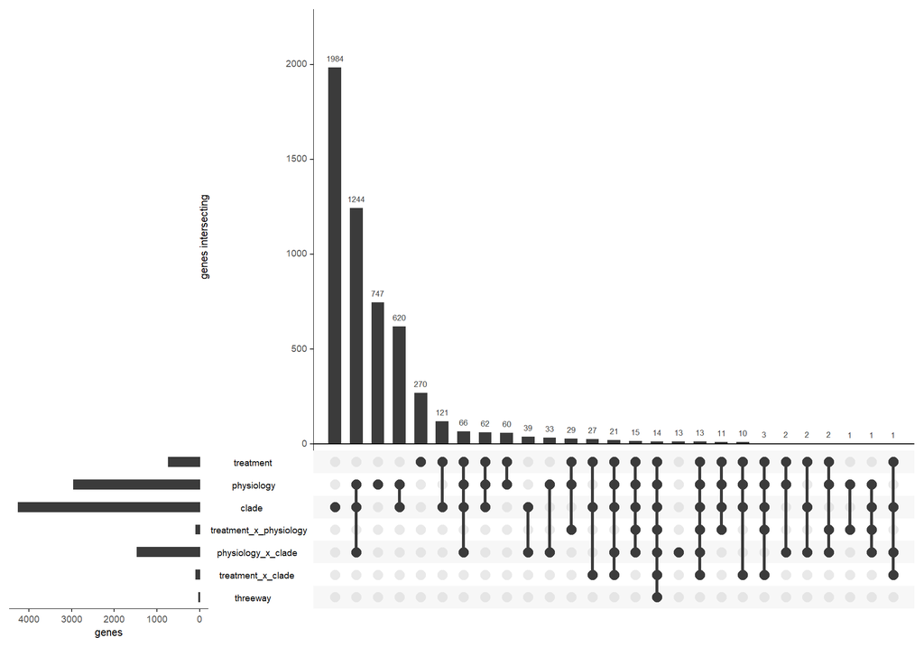

```r
listInput <- list(treatment=               treatment,
                  physiology=              physiology,
                  clade=                   clade,
                  treatment_x_physiology=  treatment_x_physiology,
                  physiology_x_clade=      physiology_x_clade,
                  treatment_x_clade=       treatment_x_clade,
                  threeway=                threeway)

#png("C:/Users/jmcgirr/Documents/" , width = 12, height = 7, units = 'in', res = 600)
upset(fromList(listInput), sets = rev(names(listInput)),order.by = "freq",
      point.size = 3.4, line.size = 1.2,
      mainbar.y.label = "genes intersecting", sets.x.label = "genes",keep.order = TRUE)
```

```r
#dev.off()
```

## Conserved expression response to osmotic stress across all species.

-Genes show the same response to osmotic stress across all species, regardless of native physiology. - Same fold-change expression response to osmotic stress. - Significant for main effect of treatment but not significant for (treatment x physiology) and not significant for (treatment x physiology x clade interactions). - `gls(counts~treatment[FW or BW])`

### Example genes: ctfr and aqp3

ctfr is significantly upregulated in all species transferred to BW after 2 weeks. aqp3 is downregulated.

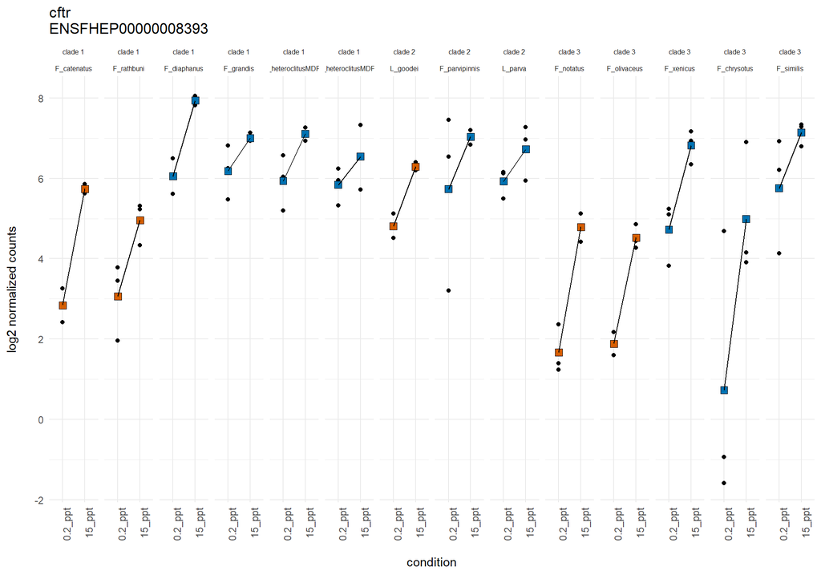

```r
experiment <- "BW"
comp <- "main_salinity"
gene_id <- c("ENSFHEP00000008393")

counts <- all_samples_single_gene(gene_id,comp,experiment)

p1<-ggplot(counts, aes(x=condition, y=gene, col = species, fill = physiology)) +
  geom_point()+
    theme_minimal()+
    ylab("log2 normalized counts\n")+
    xlab("\ncondition")+
    scale_fill_manual(values=c(blu,red))+
    scale_color_manual(values = c(rep("black",28)))+
    ggtitle(paste("cftr\n", gene_id, sep = ""))+
    facet_wrap(~clade + species, ncol = 14)+
    stat_summary(geom = "point",fun = "mean",size = 3,shape = 22,aes(fill =physiology))+
    stat_summary(geom = "line",fun = "mean",col = "black",aes(group = 1))+
    theme(axis.text.x = element_text(angle=90, hjust=1))+
    theme(strip.text.x = element_text(size = 6))+
    theme(legend.position = "none")

#png(paste("C:/Users/jmcgirr/Documents/Whitehead_Lab/fun/figs/genes/",gene_name, "_",comp,"_exp_transfer.png",sep = ""), height = 4.5, width = 12, units = 'in', res = 600)
print(p1)
```

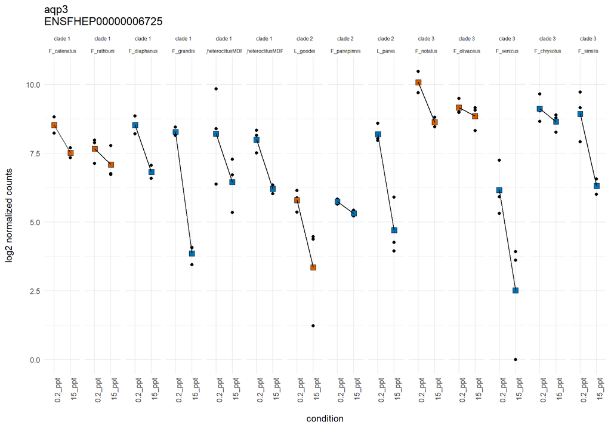

```r
#dev.off()


gene_id <- c("ENSFHEP00000006725")

counts <- all_samples_single_gene(gene_id,comp,experiment)

p1<-ggplot(counts, aes(x=condition, y=gene, col = species, fill = physiology)) +
  geom_point()+
    theme_minimal()+
    ylab("log2 normalized counts\n")+
    xlab("\ncondition")+
    scale_fill_manual(values=c(blu,red))+
    scale_color_manual(values = c(rep("black",28)))+
    ggtitle(paste("aqp3\n", gene_id, sep = ""))+
    facet_wrap(~clade + species, ncol = 14)+
    stat_summary(geom = "point",fun = "mean",size = 3,shape = 22,aes(fill =physiology))+
    stat_summary(geom = "line",fun = "mean",col = "black",aes(group = 1))+
    theme(axis.text.x = element_text(angle=90, hjust=1))+
    theme(strip.text.x = element_text(size = 6))+
    theme(legend.position = "none")

#png(paste("C:/Users/jmcgirr/Documents/Whitehead_Lab/fun/figs/genes/",gene_name, "_",comp,"_exp_transfer.png",sep = ""), height = 4.5, width = 12, units = 'in', res = 600)
print(p1)
```

```r
#dev.off()
```

### Heatmap: Genes showing significant BW response after 2 weeks

- These genes show the same type of expression pattern as cftr and aqp3.
  - log2(mean.species.BW) - log2(mean.species.FW)

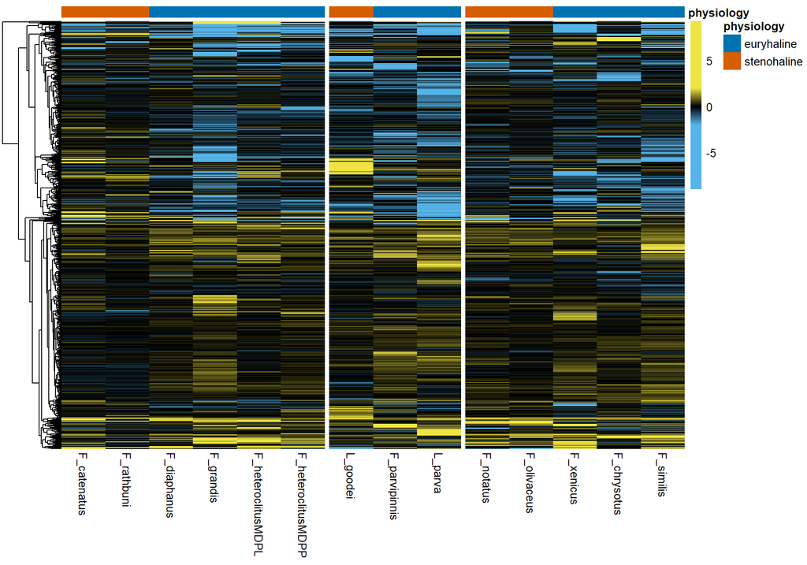

## Diverged expression between physiologies regardless of osmotic environment.

- Diverged expression between euryhaline and stenohaline. Expression levels in each species do not change between treatments.
  - Significant for main effect of physiology but not significant for (treatment x physiology) or (treatment x physiology x clade) interactions.
  - Should this also exclude (physiology x clade) interactions?
  - `gls(counts~physiology[euryhaline or stenohaline])`

### Example genes: slc35a3a and exoc7

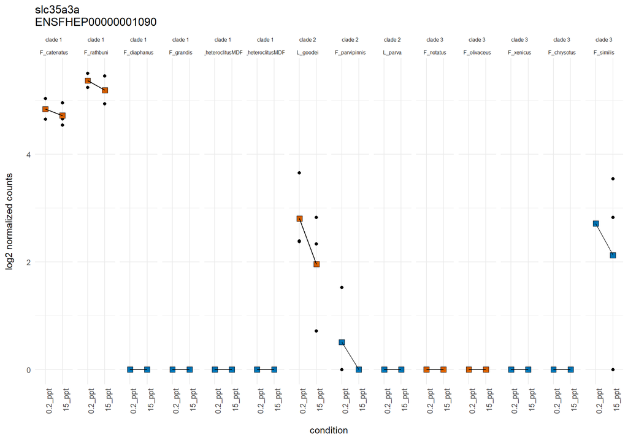

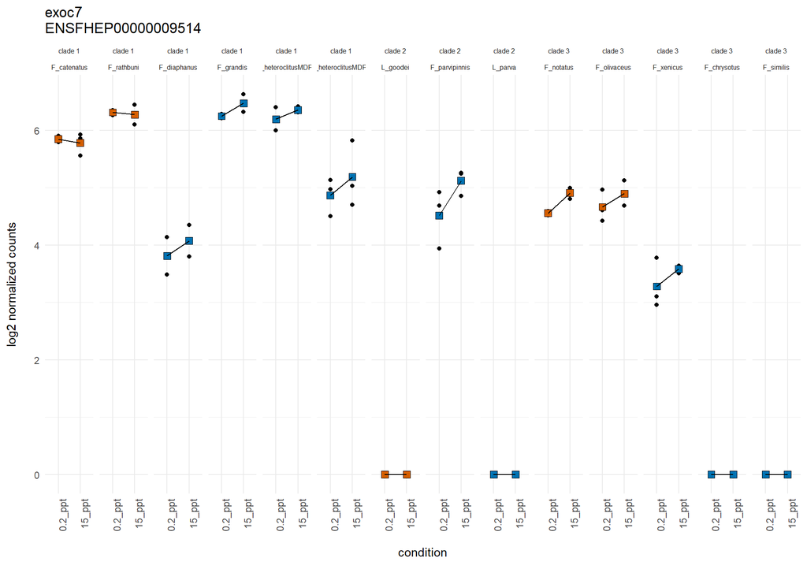

- These genes show the same type of expression pattern as slc35a3a and exoc7.
  - log2(mean.species) - log2(grand.mean.clade)

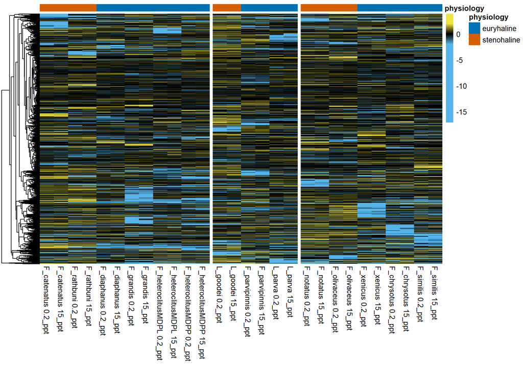

## Diverged expression responses in euryhaline versus steonhaline physiologies.

- Fold-change expression responses dependent on physiology.
  - Significant for (treatment x physiology) interaction but not for (treatment x physiology x clade) interactions.
  - Should this also exclude (physiology x clade) interactions?
  - `gls(counts~treatment[FW or BW] x physiology[euryhaline or stenohaline])`

### Example genes: per3 and per1b

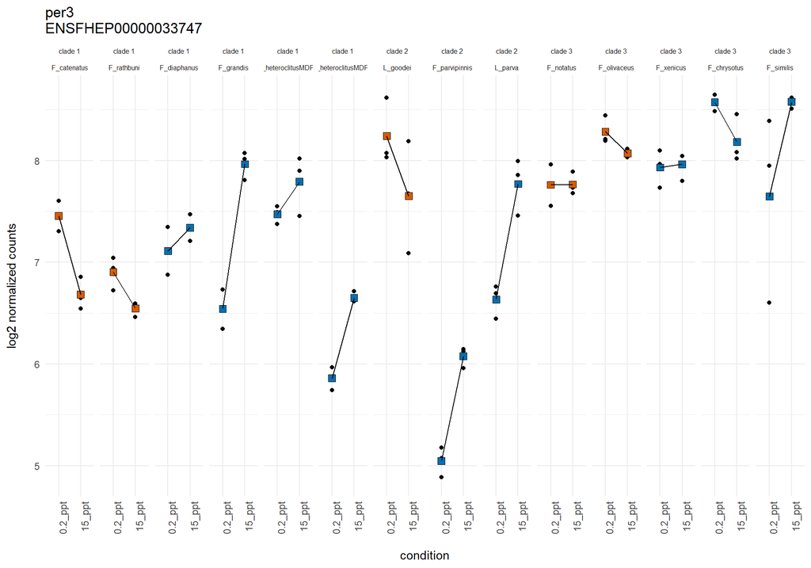

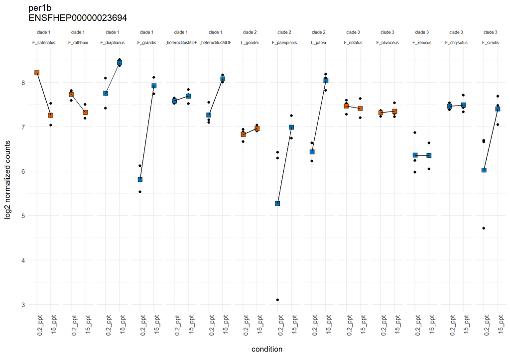

### Heatmap: Genes showing significant treatment x physiology

- These genes show the same type of expression pattern as per3 and per1b.
  - log2(mean.species.BW) - log2(mean.species.FW)

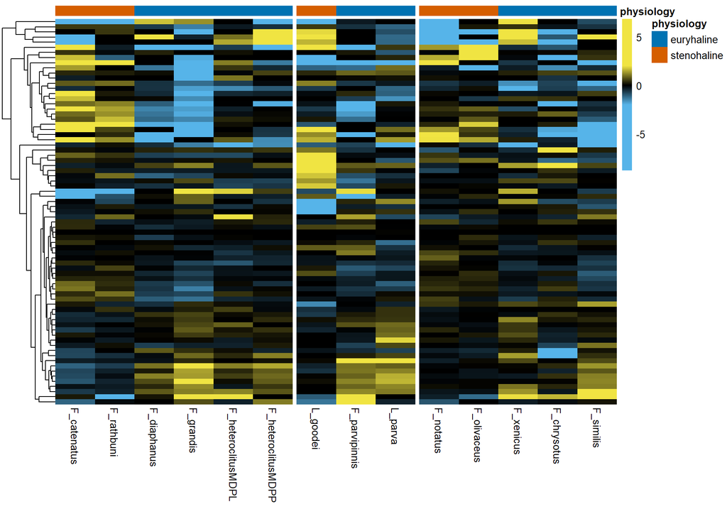